# Tarea1. Microarray, un experimento y su normalización

Roxana Andreea Moldovan Moldovan

2022-06-11

# 1. Elección del experimento:

## Datos del exprimento:

Los datos del experimento se encuentran disponibles en ArrayExpress (E-GEOD-75759) y GEO (GSE75759).

## Información relevante:

### Expression data from male cynomolgus macaques exposed to 6 ppm formaldehyde

# 2. Carga de datos:

## Paquetes empleados:

```r
library(PacRoxanaMoldovan)
# Paquetes directamente relacionados con los datos y su procesamiento:
pacman::p_load(ArrayExpress, Biobase, oligo, pd.cyngene.1.0.st)
# Otros paquetes empleados:
pacman::p_load(magick, stringr, jsonlite)
```

## Descarga de datos del experimento:

```r
# Descarga de datos desde ArrayExpress:
geod75759_raw = ArrayExpress("E-GEOD-75759")
# Guardado de datos:
f_out = "geod75759_raw.rda"
save(geod75759_raw, file = paste0(dir_datos,f_out))
```

## Guardado de datos sin procesar:

```r
# Carga de datos del fichero
load(paste0(dir_datos,"geod75759_raw.rda"))
```

## Información básica:

- El objeto que tenemos es de tipo:

```r
  class(geod75759_raw)
```

```
## [1] "GeneFeatureSet"
## attr(,"package")
## [1] "oligoClasses"
```

- Anotación:

```r
  cat("La plataforma empleada para la anotación es",
      annotation(geod75759_raw), "\n")
```

```
## La plataforma empleada para la anotación es pd.cyngene.1.0.st
```

- Experimento:

```r
n_sondas <- (dim(exprs(geod75759_raw)))[1]
n_muestras <- dim(exprs(geod75759_raw))[2]
  cat("El experimento presenta ", n_sondas, " sondas que se corresponden con ",
      n_muestras, " muestras.")
```

```
## El experimento presenta  1416100  sondas que se corresponden con  18  muestras.
```

- Representación de un microarray al azar:

```r
n_muestra <- sample(1:n_muestras, 1) # Escogemos una muestra al azar
png(paste0(dir_fig,"microarray", n_muestra, "_image.png"))
image(geod75759_raw[,n_muestra])
dev.off()
```

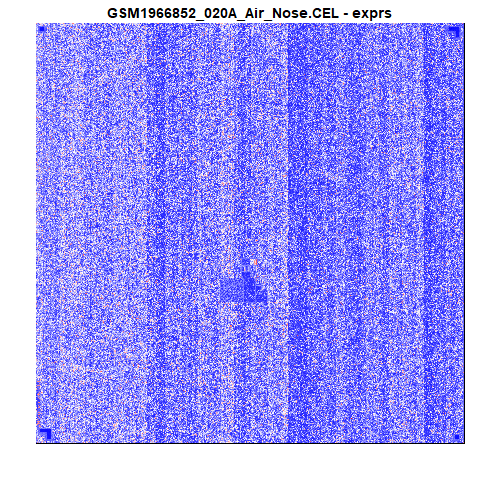

Fig1. Imagen digital de los niveles de expresión de una muestra perteneciente a geod75759.

```r
fig1 <- knitr:: include_graphics(paste0(dir_fig,"microarray",
                                        n_muestra, "_image.png"))
fig1
```

# 3. Estudio sobre la calidad de las muestras sin procesar:

En este apartado evaluaremos la calidad de los componentes de nuestro experimento con el objetivo de determinar la necesidad de descartar total o parcialmente alguna muestra en caso de ser necesario.

## MA-plot

Los **MA plots** son una aplicación del dibujo media-diferencia de Tukey que nos permiten observar la variabilidad para un mismo gen y determinar posibles arrays candidatos a ser descartados del estudio además de la necesitamos homogeneizar los valores para las distintas muestras.

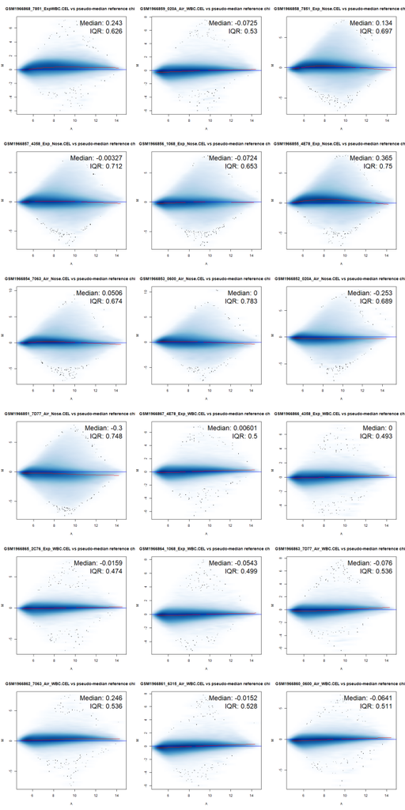

Fig2. MA-plot de las 18 muestras del estudio geod75759 antes del procesamiento.

```r
# Representación y guardado de los gráficos:
for (i in 1:n_muestras){
  png(paste0(dir_fig,"MAplot_geod75759_raw_", i, ".png"))
  oligo :: MAplot(geod75759_raw, which=i,plot.method="smoothScatter")
  dev.off()
}
```

## Estimadores de densidad.

Mediante los estimadores de densidad podemos observar los niveles de expresión de las sondas de cada uno de los arrays y así estimar los niveles de ruido.

En este caso se emplean los estimadores kernel de la densidad de las expresiones de cada array que compone la muestra.

```r
# Representación y guardado de los estimadores de densidad:
png(paste0(dir_fig,"Densidad_geod75759_raw.png"))
oligo::hist(geod75759_raw, which="all",
            main= "A.Estimadores kernel de geod75759 sin normalizar.",
            ylab="Densidad", xlab="Log2 Intensidad", xaxt="n")
dev.off()
```

Los resultados se muestran en la **Figura3 A** .

## Diagramas de cajas.

De forma análoga a los estimadores de densidad el empleo de box-plots nos permite evaluar la variabilidad de los niveles de expresión para cada array y entre los arrays del experimento.

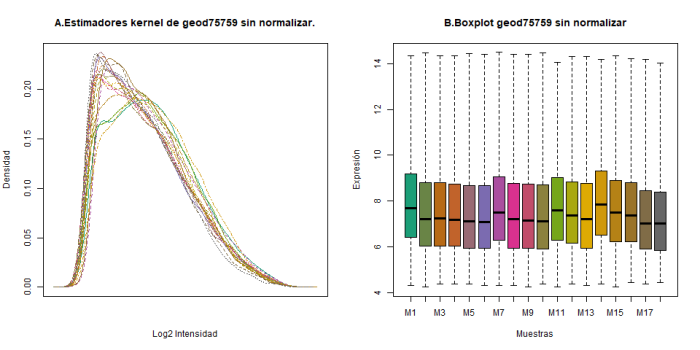

Fig3. Evaluación de la variabilidad de los niveles de expresión entre arrays en el experimento geod75759. a.Estimador kernel de densidad de los niveles de intensidad entre microarrays. b. Diagrama de cajas con bigotes de los niveles de expresión a nivel de sonda.

```r
# Representación y guardado del box-plot:
png(paste0(dir_fig,"BoxPlot_geod75759_raw.png"))
oligo::boxplot(geod75759_raw, which = "all",
               main= "B.Boxplot geod75759 sin normalizar",
               ylab="Expresión", xlab="Muestras", xaxt="n")
               axis(1, at=c(1:18),labels = paste0("M",c(1:18)))
dev.off()
```

# 4. Procesamiento de los datos mediente RMA.

Como método de procesamiento emplearemos el **Robust Multichip Averege (RMA)**, este método permite trabajar de forma simultanea con todos los arrays permitiendo la corrección de los ruidos y la variabilidad.

```r
# Normalización:
geod75759_rma <- rma(geod75759_raw)
```

```
## Background correcting
## Normalizing
## Calculating Expression
```

```r
# Numero de sondas y de muestras:
n_sondas2 <- (dim(exprs(geod75759_rma)))[1]
n_muestras2 <- dim(exprs(geod75759_rma))[2]
  cat("Trans la normalización tenemos ", n_sondas2,
      " sondas, que se corresponden con ", n_muestras2, " muestras.")
```

```
## Trans la normalización tenemos  43048  sondas, que se corresponden con  18  muestras.
```

# 5. Estudio sobre la calidad de las muestras procesadas:

## Estimadores de densidad.

```r
# Representación y guardado de los estimadores de densidad:
png(paste0(dir_fig,"Densidad_geod75759_rma.png"))
oligo::hist(geod75759_rma,
            main= "A.Estimadores kernel de geod75759 tras normalizar.",
            ylab="Densidad", xlab="Log2 Intensidad", xaxt="n")
dev.off()
```

La representación se corresponde con la **Figura 4A**.

## Diagramas de cajas.

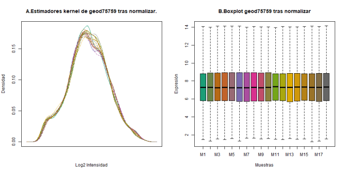

Fig4. Evaluación de la variabilidad de los niveles de expresión entre arrays en el experimento geod75759. a.Estimador kernel de densidad de los niveles de intensidad entre microarrays. b. Diagrama de cajas con bigotes de los niveles de expresión a nivel de sonda.

```r
# Representación y guardado del box-plot:
png(paste0(dir_fig,"BoxPlot_geod75759_rma.png"))
oligo::boxplot(geod75759_rma,
               main= "B.Boxplot geod75759 tras normalizar",
               ylab="Expresión", xlab="Muestras", xaxt="n")
               axis(1, at=c(1:18),labels = paste0("M",c(1:18)))
dev.off()
```

# 6. Incorporación de información al ExpressionSet

## Información del experimento.

Los datos del experimento se introducen en formato MIAME.

```r
dat_ex <- new("MIAME", name = "E-GEOD-75759",
              lab = "Environmental Sciences and Engineering, UNC-Chapel Hill",
              contact ="rfry@unc.edu",
              title = paste0("Expression data from male cynomolgus macaques",
              " exposed to 6 ppm formaldehyde."),
              abstract = paste0("Exogenous formaldehyde disrupts genomic/",
              " epigenomic profiles in the rodent nose and white blood cells",
              " (WBCs) related to inflammation and immune signaling, although",
              " it does not reach the circulating blood. We aimed to compare",
              " and contrast alterations in genomic signaling in the nose and",
              " circulating blood of non-human primates exposed to",
              " formaldehyde. We used microarrays to identify transcripts",
              " that were diffentially expressed in response to formaldehyde",
              " inhalation exposure. A total of 14 primates received two",
              " consecutive days of 6-hour whole body inhalation exposures",
              " consisting of either filtered air (n = 6) or a target of 6",
              " ppm formaldehyde (n = 8). To assess formaldehyde-induced",
              " changes in genome-wide gene expression profiles, RNA samples",
              " extracted from the nasal epithelium and circulating WBCs were",
              " labeled and hybridized to the Affymetrix Cynomolgus Macaque",
              " Gene 1.0 ST Array."),
              url = paste0("https://www.ebi.ac.uk/arrayexpress/",
                           "experiments/E-GEOD-75759/"),
              other = list(notes = paste0("Released on 30 June 2016, ",
                                          "last updated on 24 July 2016")))
experimentData(geod75759_rma) = dat_ex
experimentData(geod75759_rma)
```

```
## Experiment data
##   Experimenter name: E-GEOD-75759
##   Laboratory: Environmental Sciences and Engineering, UNC-Chapel Hill
##   Contact information: rfry@unc.edu
##   Title: Expression data from male cynomolgus macaques exposed to 6 ppm formaldehyde.
##   URL: https://www.ebi.ac.uk/arrayexpress/experiments/E-GEOD-75759/
##   PMIDs:
##
##   Abstract: A 132 word abstract is available. Use 'abstract' method.
##   notes:
##    notes:
##       Released on 30 June 2016, last updated on 24 July 2016
```

## Datos fenotípicos.

En este apartado veremos los datos fenotipos asociados a nuestro estudio.

```r
# Mostramos la variable fenotipicas asociadas a nuestra muestra:
datos_fenotipicos <- pData(geod75759_rma)
head(datos_fenotipicos, n=1)
```

```
##                             Source.Name
## GSM1966868_7851_ExpWBC.CEL GSM1966868 1
##                                                                                                                                                        Comment..Sample_description.
## GSM1966868_7851_ExpWBC.CEL Gene expression data from circulating white blood cells of cynomologus macaques exposed to filtered air for 2-day, 6-hour whole body inhalation exposure
##                                                                                                                                Comment..Sample_source_name.
## GSM1966868_7851_ExpWBC.CEL white blood cells from male cynomolgous macaque collected immediately following the second 6-hour exposure to 6 ppm formaldehyde
##                            Comment..Sample_title. Characteristics..organism.
## GSM1966868_7851_ExpWBC.CEL  WBC_Formaldehyde_Rep5        Macaca fascicularis
##                            Term.Source.REF
## GSM1966868_7851_ExpWBC.CEL             EFO
##                                                    Term.Accession.Number
## GSM1966868_7851_ExpWBC.CEL http://purl.obolibrary.org/obo/NCBITaxon_9541
##                            Characteristics..organism.part.
## GSM1966868_7851_ExpWBC.CEL   circulating white blood cells
##                            Characteristics..sex. Term.Source.REF.1
## GSM1966868_7851_ExpWBC.CEL                  male               EFO
##                                                Term.Accession.Number.1
## GSM1966868_7851_ExpWBC.CEL http://purl.obolibrary.org/obo/PATO_0000384
##                            Protocol.REF Term.Source.REF.2 Protocol.REF.1
## GSM1966868_7851_ExpWBC.CEL P-GSE75759-2      ArrayExpress   P-GSE75759-3
##                            Term.Source.REF.3         Extract.Name Material.Type
## GSM1966868_7851_ExpWBC.CEL      ArrayExpress GSM1966868 extract 1     total RNA
##                            Protocol.REF.2 Term.Source.REF.4
## GSM1966868_7851_ExpWBC.CEL   P-GSE75759-4      ArrayExpress
##                            Labeled.Extract.Name
## GSM1966868_7851_ExpWBC.CEL      GSM1966868 LE 1
##                                                                                                                                                         Label
## GSM1966868_7851_ExpWBC.CEL terminal deoxynucleotidyl transferase (TdT) in the presence of a proprietary biotinylated compound, GeneChip® DNA Labeling Reagent
##                            Protocol.REF.3 Term.Source.REF.5 Assay.Name
## GSM1966868_7851_ExpWBC.CEL   P-GSE75759-5      ArrayExpress GSM1966868
##                            Array.Design.REF Term.Source.REF.6 Technology.Type
## GSM1966868_7851_ExpWBC.CEL     A-GEOD-21213      ArrayExpress     array assay
##                            Protocol.REF.4 Term.Source.REF.7
## GSM1966868_7851_ExpWBC.CEL   P-GSE75759-6      ArrayExpress
##                                       Array.Data.File
## GSM1966868_7851_ExpWBC.CEL GSM1966868_7851_ExpWBC.CEL
##                                                                                                  Comment..ArrayExpress.FTP.file.
## GSM1966868_7851_ExpWBC.CEL ftp://ftp.ebi.ac.uk/pub/databases/microarray/data/experiment/GEOD/E-GEOD-75759/E-GEOD-75759.raw.1.zip
##                            Protocol.REF.5 Term.Source.REF.8
## GSM1966868_7851_ExpWBC.CEL   P-GSE75759-1      ArrayExpress
##                                          Normalization.Name
## GSM1966868_7851_ExpWBC.CEL GSM1966868_sample_table.txt norm
##                                Derived.Array.Data.File
## GSM1966868_7851_ExpWBC.CEL GSM1966868_sample_table.txt
##                                                                                                Comment..Derived.ArrayExpress.FTP.file.
## GSM1966868_7851_ExpWBC.CEL ftp://ftp.ebi.ac.uk/pub/databases/microarray/data/experiment/GEOD/E-GEOD-75759/E-GEOD-75759.processed.1.zip
##                              FactorValue..organism.part.
## GSM1966868_7851_ExpWBC.CEL circulating white blood cells
```

En este ensayo podemos dividir las muestras en varios grupos.  
Por un lado tenemos dos tipos de muestras según el tejido de proveniencia:

- **WBC** -> *Circulating white blood cells*
- **NE** -> *Nasal epithleium*

Y dos tipos de muestra según el tratamiento al que los sujetos han sido sometidos antes de la extracción de la muestra:

- **Formaldehyde** -> Sujetos expuestos a formaldeido.
- **Filtered_Air** -> Sujetos expuestos a aire filtrado.

Esta información se define en las variables fenotípicas de tipo char: **Characteristics..organism.part.**, **Comment..Sample_source_name** y **Comment..Sample_title.** , aunque sería interesante la incorporación de variables de tipo factor que definan estos parámetros.

### Definición de factores

```r
# Factor que define el tipo de muestra:
tipo_muestra <- factor(c(0,0,0,0,0,0,0,0,0,0,1,1,1,1,1,1,1,1),
                       levels = 0:1, labels = c("WBC", "NE"))

# Factor que describe el tratamiento de la muestra:
tratamiento <- factor(c(0,0,0,0,0,1,1,1,1,1,0,0,0,0,1,1,1,1),levels = 0:1,
                      labels = c("Formaldehyde", "Filtered_Air"))

# Completamos los datos con los nuevos factores en el orden conveniente
datos_fenotipicos2 <- data.frame("Source.Name" = datos_fenotipicos$Source.Name,
                                 "Sample_type" = tipo_muestra,
                                 "Sample_treatment" = tratamiento,
                                 datos_fenotipicos[,2:37])

pData(geod75759_rma) <- datos_fenotipicos2
```

```r
# Mostramos los datos fenotípicos de la primera y última muestra:
(pData(geod75759_rma)[c(1,14),])
```

```
##                               Source.Name Sample_type Sample_treatment
## GSM1966868_7851_ExpWBC.CEL   GSM1966868 1         WBC     Formaldehyde
## GSM1966855_4E78_Exp_Nose.CEL GSM1966855 1          NE     Formaldehyde
##                                                                                                                                                          Comment..Sample_description.
## GSM1966868_7851_ExpWBC.CEL   Gene expression data from circulating white blood cells of cynomologus macaques exposed to filtered air for 2-day, 6-hour whole body inhalation exposure
## GSM1966855_4E78_Exp_Nose.CEL         Gene expression data from nasal epithleium of cynomologus macaques exposed to 6ppm formaldehyde for 2-day, 6-hour whole body inhalation exposure
##                                                                                                                                  Comment..Sample_source_name.
## GSM1966868_7851_ExpWBC.CEL   white blood cells from male cynomolgous macaque collected immediately following the second 6-hour exposure to 6 ppm formaldehyde
## GSM1966855_4E78_Exp_Nose.CEL      nasal epithleium of male cynomolgus macaque collected immediately following the second 6-hour exposureto 6 ppm formaldehyde
##                              Comment..Sample_title. Characteristics..organism.
## GSM1966868_7851_ExpWBC.CEL    WBC_Formaldehyde_Rep5        Macaca fascicularis
## GSM1966855_4E78_Exp_Nose.CEL Nose_Formaldehyde_Rep1        Macaca fascicularis
##                              Term.Source.REF
## GSM1966868_7851_ExpWBC.CEL               EFO
## GSM1966855_4E78_Exp_Nose.CEL             EFO
##                                                      Term.Accession.Number
## GSM1966868_7851_ExpWBC.CEL   http://purl.obolibrary.org/obo/NCBITaxon_9541
## GSM1966855_4E78_Exp_Nose.CEL http://purl.obolibrary.org/obo/NCBITaxon_9541
##                              Characteristics..organism.part.
## GSM1966868_7851_ExpWBC.CEL     circulating white blood cells
## GSM1966855_4E78_Exp_Nose.CEL                nasal epithleium
##                              Characteristics..sex. Term.Source.REF.1
## GSM1966868_7851_ExpWBC.CEL                    male               EFO
## GSM1966855_4E78_Exp_Nose.CEL                  male               EFO
##                                                  Term.Accession.Number.1
## GSM1966868_7851_ExpWBC.CEL   http://purl.obolibrary.org/obo/PATO_0000384
## GSM1966855_4E78_Exp_Nose.CEL http://purl.obolibrary.org/obo/PATO_0000384
##                              Protocol.REF Term.Source.REF.2 Protocol.REF.1
## GSM1966868_7851_ExpWBC.CEL   P-GSE75759-2      ArrayExpress   P-GSE75759-3
## GSM1966855_4E78_Exp_Nose.CEL P-GSE75759-2      ArrayExpress   P-GSE75759-3
##                              Term.Source.REF.3         Extract.Name
## GSM1966868_7851_ExpWBC.CEL        ArrayExpress GSM1966868 extract 1
## GSM1966855_4E78_Exp_Nose.CEL      ArrayExpress GSM1966855 extract 1
##                              Material.Type Protocol.REF.2 Term.Source.REF.4
## GSM1966868_7851_ExpWBC.CEL       total RNA   P-GSE75759-4      ArrayExpress
## GSM1966855_4E78_Exp_Nose.CEL     total RNA   P-GSE75759-4      ArrayExpress
##                              Labeled.Extract.Name
## GSM1966868_7851_ExpWBC.CEL        GSM1966868 LE 1
## GSM1966855_4E78_Exp_Nose.CEL      GSM1966855 LE 1
##                                                                                                                                                           Label
```

[output cut: 17 more lines]

```
##                              Protocol.REF.5 Term.Source.REF.8
## GSM1966868_7851_ExpWBC.CEL     P-GSE75759-1      ArrayExpress
## GSM1966855_4E78_Exp_Nose.CEL   P-GSE75759-1      ArrayExpress
##                                            Normalization.Name
## GSM1966868_7851_ExpWBC.CEL   GSM1966868_sample_table.txt norm
## GSM1966855_4E78_Exp_Nose.CEL GSM1966855_sample_table.txt norm
##                                  Derived.Array.Data.File
## GSM1966868_7851_ExpWBC.CEL   GSM1966868_sample_table.txt
## GSM1966855_4E78_Exp_Nose.CEL GSM1966855_sample_table.txt
##                                                                                                  Comment..Derived.ArrayExpress.FTP.file.
## GSM1966868_7851_ExpWBC.CEL   ftp://ftp.ebi.ac.uk/pub/databases/microarray/data/experiment/GEOD/E-GEOD-75759/E-GEOD-75759.processed.1.zip
## GSM1966855_4E78_Exp_Nose.CEL ftp://ftp.ebi.ac.uk/pub/databases/microarray/data/experiment/GEOD/E-GEOD-75759/E-GEOD-75759.processed.1.zip
##                                FactorValue..organism.part.
## GSM1966868_7851_ExpWBC.CEL   circulating white blood cells
## GSM1966855_4E78_Exp_Nose.CEL              nasal epithleium
```

Finalmente podemos observar las tablas de frecuencias absolutas de los factores que definen las muestras.

```r
# Descripción de la covariante Sample_type:
table(geod75759_rma$Sample_type)
```

```
##
## WBC  NE
##  10   8
```

```r
# Descripción de la covariante Sample_type:
table(geod75759_rma$Sample_treatment)
```

```
##
## Formaldehyde Filtered_Air
##            9            9
```

### Anotación:

No se dispone de una base de datos adecuada para llevar a cabo la anotación por lo que se ha tomado la información y la correlación de los identificadores de nuestras sondas con identificadores típicos de genes desde [Current NetAffx Annotation Files: CynGene-1_0-st-v1 Probeset Annotations, CSV Format, Release 34](https://www.thermofisher.com/order/catalog/product/901941).

```r
dir_expression_set = paste0(dir_datos, "ExpressionSet/")
platform = read.table(paste0(dir_expression_set,
"TFS-Assets_LSG_Support-Files_CynGene-1_0-st-v1-na34-cm1-transcript-csv", "/",
                             "CynGene-1_0-st-v1.na34.cm1.transcript.csv"),
                      sep=",", header = TRUE)
```

Una vez cargados los datos podemos observar la información de la que disponemos:

```r
# Mostramos los identificadores de las columnas:
colnames(platform)
```

```
##  [1] "transcript_cluster_id" "probeset_id"           "seqname"
##  [4] "strand"                "start"                 "stop"
##  [7] "total_probes"          "gene_assignment"       "mrna_assignment"
## [10] "swissprot"             "unigene"               "GO_biological_process"
## [13] "GO_cellular_component" "GO_molecular_function" "pathway"
## [16] "protein_domains"       "crosshyb_type"         "category"
```

De esta información nos resulta interesante centrarnos en **probeset_id** que se corresponde con el identificador de las sondas y nos permitirá determinar la coincidencia entre nuestros datos y otros identificadores.

```r
# Mostramos los primeros identificadores.
head(rownames(fData(geod75759_rma)))
```

```
## [1] "13575001" "13575003" "13575005" "13575007" "13575009" "13575011"
```

```r
head(platform$probeset_id)
```

```
## [1] 13579638 13579648 13579650 13579671 13579680 13579687
```

Incorporamos toda la información a nuestras sondas:

```r
# Ahora que que tenemos la información de las sondas buscamos correspondencias:
ID = data.frame("id"=as.numeric(featureNames(geod75759_rma)))
anot <- merge(ID, platform, by.x="id", by.y="probeset_id", all.x=TRUE)

head(anot, 2)
```

```
##         id transcript_cluster_id seqname strand start stop total_probes
## 1 13575001              13575001     ---    ---   ---  ---            4
## 2 13575003              13575003     ---    ---   ---  ---            3
##   gene_assignment mrna_assignment swissprot unigene GO_biological_process
## 1             ---             ---       ---     ---                   ---
## 2             ---             ---       ---     ---                   ---
##   GO_cellular_component GO_molecular_function pathway protein_domains
## 1                   ---                   ---     ---             ---
## 2                   ---                   ---     ---             ---
##   crosshyb_type         category
## 1           --- normgene->intron
## 2           --- normgene->intron
```

Por otro lado, toda la información sobre identificadores que utilizaremos se encuentra en contenida en **gene_assignment**, por lo que hay que extraerla.

La disposición de estos datos se explican en el fichero README ( *GeneArray_NetAffx-CSV-Files.README.txt* ) disponible en el directorio *docs*.

```
Within each column value, two types of field delimiters may appear:

  * " /// " - separates annotations for different mRNAs and also
              separates multiple annotations of a particular type
              for a given mRNA. The mRNA to which the annotation
              applies is identified by the first data type
              sub-field of the annotation.

  * " // "  - separates different data type sub-fields for a
              single mRNA annotation.
Note that the spaces surrounding the forward slashes are
considered part of the delimiter.


An empty value (null) is indicated by three hyphens "---".


III.B.8. gene_assignment  (multipart)

  Gene information for each assigned mRNA for mRNAs that corresponds
  to known genes.

  Sub-fields:
    a. accession       - public sequence identifier for mRNA
    b. gene symbol     - gene name if mRNA corresponds to a known gene
    c. gene title      - description of gene product
    d. cytoband        - cytogenetic location of gene
    e. entrez gene id  - Entrez Gene database identifier
```

Por consiguiente, en primer lugar deberemos separar la columna por *” /// “* para obtener las distintas posibles anotaciones (y por lo tanto genes) con los que se corresponde cada sonda.

A continuación, separaremos nuevamente cada anotación según *” // “* para extraer la información disponible en un data frame.

Las anotaciones pueden pertenecer a varias bases de datos, nosotros nos quedaremos con las de Ensembl (sabemos que su identificador comienza con *“ENS”* ).

Finalmente tomaremos las columnas **accession**, que se corresponde con el identificador **Ensembl**, **gene symbol**, que se corresponde con una denominación del gen, y **entrez gene id** que es el identificador de **Entrez** de la NCBI.

Cabe mencionar que en pasos posteriores nos interesa quedarnos únicamente con las sondas que disponen de un identificador **ENTRZID**, por tanto, durante todo este proceso iremos descartando las sondas que presenten un valor *“- - -”* en las columnas **gene_assignment** o posteriormente **entrez gene id**, y que por consiguiente no presentan identificadores **ENTREZID**.

```r
# Eliminamos las sondas sin gene_assignment (no se corresponden con genes):
anot2 <- anot[!(anot$gene_assignment == "---"),]

# Nos centramos en el gene_assigment que tiene la info que nos interesa:
# Múltiples anotaciones par aun mismo gen estas separadas por ' /// ':
opciones_anot <- (str_split(anot2$gene_assignment, " /// "))


# Creamos el data frame que contendrá la información:
datos_anot <- data.frame("accession" = character(), "gene_symbol" = character(),
                         "gene_title" = character(), "cytoband"== character(),
                         "entrez_gene_id"=numeric())

# Nos quedamos con las anotaciones de Ensembl, que comienzan por 'ENS':
for (x in (1:length(opciones_anot))){ # Recorremos la lista de todas las sondas.
  opcion = opciones_anot[[x]]

  for (i in opcion){ # Recorremos las posibles anotaciones.

    # Comprobamos si los primeros caracteres coinciden con 'ENS':
    j = substr(i, start = 1, stop = 3)
    if (j == "ENS"){

      # Separamos la información de la anotación por ' // '
      inf = (str_split(i, " // "))[[1]]

      #Descartamos las sondas que tengan '---' en el elemento 5.
      if (inf[5]!= "---"){

        # Tomamos el identificador de dicha posición:
        id = anot2[x,1]
        nuevo <- data.frame (PROBEID = id, ENTREZID = inf[5],
                             ENSEMBLTRANS = inf[1] , GENSYMBOL = inf[2])
        # Lo añadimos al data frame las columnas deseadas:
        datos_anot <- rbind(datos_anot,nuevo)
      }
    }
  }
}
```

Visualizamos los datos de la anotación actual:

```r
head(datos_anot)
```

```
##    PROBEID ENTREZID       ENSEMBLTRANS GENSYMBOL
## 1 13579638   699677 ENSMMUT00000032498    LRPAP1
## 2 13579671   720098 ENSMMUT00000011722 LOC720098
## 3 13579689   722333 ENSMMUT00000001640 LOC722333
## 4 13579692   722339 ENSMMUT00000047703 LOC722339
## 5 13579703   722345 ENSMMUT00000001636 LOC722345
## 6 13579703   722345 ENSMMUT00000001638 LOC722345
```

Si nos fijamos en los identificadores de Ensembl.

```r
head(datos_anot$ENSEMBLTRANS)
```

```
## [1] "ENSMMUT00000032498" "ENSMMUT00000011722" "ENSMMUT00000001640"
## [4] "ENSMMUT00000047703" "ENSMMUT00000001636" "ENSMMUT00000001638"
```

Observamos que el séptimo carácter de este es un T, esto nos indica que se trata de identificador del transcrito, pero nos interesaría también obtener el del gen (si es que presenta).

Para ello usaremos la base de datos **VGNC** que nos permite descargar la información relativa a los genes de macaco.

Descargaremos el fichero json.

La información disponible en esta es:

```r
db <- fromJSON(paste0(dir_expression_set, "macaque_vgnc_gene_set_All.json"))
colnames(db)
```

```
##  [1] "location"               "date_modified"          "vgnc_id"
##  [4] "locus_group"            "ncbi_id"                "date_approved_reserved"
##  [7] "symbol"                 "location_sortable:"     "ensembl_gene_id"
## [10] "name"                   "uniprot_ids"            "locus_type"
## [13] "status"                 "date_name_changed"      "prev_name"
## [16] "alias_name"             "prev_symbol"            "alias_symbol"
## [19] "date_symbol_changed"
```

Usaremos las correspondencias entre los **ENTREZID** de nuestras sondas y los **ncbi_id** de la base de datos.

```r
a <- (merge(datos_anot, db, by.x="ENTREZID", by.y="ncbi_id", all.x=TRUE))
datos_anot <- data.frame(a[,1:4], ENSAMBL=a$ensembl_gene_id)
```

```r
head(datos_anot)
```

```
##    ENTREZID  PROBEID       ENSEMBLTRANS GENSYMBOL            ENSAMBL
## 1 100135775 13637316 ENSMMUT00000012015     PDCD1 ENSMMUG00000063159
## 2 100141390 13828708 ENSMMUT00000012378      LST1               <NA>
## 3 100141390 13817308 ENSMMUT00000012378      LST1               <NA>
## 4 100141390 13832618 ENSMMUT00000012378      LST1               <NA>
## 5 100141390 13835282 ENSMMUT00000012378      LST1               <NA>
## 6 100141395 13814624 ENSMMUT00000029014       CD9               <NA>
```

A continuación comprobamos si hay correspondencias multiples entre las sondas y los genes.

- ¿Existen sondas que se corresponden con más de un gen?  
  Para eso comprobaremos si tenemos identificadores PROBEID repetidos.

```r
p <- table(datos_anot$PROBEID)>1
table(p)
```

```
## p
## FALSE  TRUE
## 12497  3911
```

```r
p2 <- which(p)
```

```r
  cat("Si, encontramos", length(p2),
      "sondas que se corresponden a más de un gen.")
```

```
## Si, encontramos 3911 sondas que se corresponden a más de un gen.
```

Algunas de estas son:

```r
head (p2)
```

```
## 13579703 13579724 13580085 13580767 13580952 13581048
##        5        6       20       54       63       68
```

- ¿Existen genes que se corresponden con más de una sonda? Para eso comprobaremos si tenemos identificadores ENTREZID repetidos.

```r
g <- table(datos_anot$ENTREZID)>1
table(g)
```

```
## g
## FALSE  TRUE
## 10206  3781
```

```r
g2 <- which(g)
```

```r
  cat("Si, encontramos", length(g2),
      "genes que se corresponden a más de una sonda.")
```

```
## Si, encontramos 3781 genes que se corresponden a más de una sonda.
```

```r
head (g2)
```

```
## 100141390 100141395 100144394 100169969 100174952 100174953
##         2         3         4         7         9        10
```

Nos quedaremos con un solo gen por sonda y una sola sonda por identificador, en este caso hemos decidido quedarnos con la primera aparición:

```r
# Eliminamos sondas y genes repetidos:
a = match(unique(datos_anot$PROBEID),datos_anot$PROBEID)
datos_anot2 <- datos_anot[a,]
b = match(unique(datos_anot2$ENTREZID),datos_anot2$ENTREZID)
datos_anot3 <- datos_anot2[b,]
```

Comprobamos si la correspondencia es 1:1

```r
length(unique(datos_anot3$PROBEID)) == length(unique(datos_anot3$ENTREZID))
```

```
## [1] TRUE
```

También podemos comprobar si hay repeticiones entre los identificadores **Ensembl**, pero en este caso usarnos los identificadores de los transcritos ya que no hemos encontrado identificadores de genes para muchos de ellos.

```r
# Finalmente vemos si según los identificadores ENSEMBL hay repeticiones:
e <- (table(datos_anot3$ENSEMBL)>1)
table(e)
```

```
## e
## FALSE
## 13242
```

No se han encontrado repeticiones.

Ahora que tenemos toda la información sobre la anotación asignaremos estos datos a fData.

```r
# Asignamos los datos a fData:
c <- match(featureNames(geod75759_rma),datos_anot3$PROBEID)
fData(geod75759_rma) <- datos_anot3[c,]
# Eliminamos las sondas cuya información no está en los datos de anotación:
geod75759_rma <- geod75759_rma[which(!is.na(fData(geod75759_rma)$PROBEID),)]
```

## Guardado de datos procesados:

```r
# Guardado de datos:
f_out = "geod75759_rma.rda"
save(geod75759_rma, file = paste0(dir_datos,f_out))

# Carga de datos del fichero
load(paste0(dir_datos,f_out))
```